# analysis

### WEATHER TREND FORECASTING

### BOTH BASIC AND ADVANCED ASSESMENT

## BASIC ASSESMENT

### Initial data load

|  | country | location_name | latitude | longitude | timezone | last_updated_epoch | last_updated | temperature_celsius | temperature_fahrenheit | condition_text | ... | air_quality_PM2.5 | air_quality_PM10 | air_quality_us-epa-index | air_quality_gb-defra-index | sunrise | sunset | moonrise | moonset | moon_phase | moon_illumination |
| --- | --- | --- | --- | --- | --- | --- | --- | --- | --- | --- | --- | --- | --- | --- | --- | --- | --- | --- | --- | --- | --- |
| 0 | Afghanistan | Kabul | 34.52 | 69.18 | Asia/Kabul | 1715849100 | 2024-05-16 13:15 | 26.6 | 79.8 | Partly Cloudy | ... | 8.4 | 26.6 | 1 | 1 | 04:50 AM | 06:50 PM | 12:12 PM | 01:11 AM | Waxing Gibbous | 55 |
| 1 | Albania | Tirana | 41.33 | 19.82 | Europe/Tirane | 1715849100 | 2024-05-16 10:45 | 19.0 | 66.2 | Partly cloudy | ... | 1.1 | 2.0 | 1 | 1 | 05:21 AM | 07:54 PM | 12:58 PM | 02:14 AM | Waxing Gibbous | 55 |
| 2 | Algeria | Algiers | 36.76 | 3.05 | Africa/Algiers | 1715849100 | 2024-05-16 09:45 | 23.0 | 73.4 | Sunny | ... | 10.4 | 18.4 | 1 | 1 | 05:40 AM | 07:50 PM | 01:15 PM | 02:14 AM | Waxing Gibbous | 55 |
| 3 | Andorra | Andorra La Vella | 42.50 | 1.52 | Europe/Andorra | 1715849100 | 2024-05-16 10:45 | 6.3 | 43.3 | Light drizzle | ... | 0.7 | 0.9 | 1 | 1 | 06:31 AM | 09:11 PM | 02:12 PM | 03:31 AM | Waxing Gibbous | 55 |
| 4 | Angola | Luanda | -8.84 | 13.23 | Africa/Luanda | 1715849100 | 2024-05-16 09:45 | 26.0 | 78.8 | Partly cloudy | ... | 183.4 | 262.3 | 5 | 10 | 06:12 AM | 05:55 PM | 01:17 PM | 12:38 AM | Waxing Gibbous | 55 |

5 rows × 41 columns

```
<class 'pandas.core.frame.DataFrame'>
RangeIndex: 117323 entries, 0 to 117322
Data columns (total 41 columns):
 #   Column                        Non-Null Count   Dtype
---  ------                        --------------   -----
 0   country                       117323 non-null  object
 1   location_name                 117323 non-null  object
 2   latitude                      117323 non-null  float64
 3   longitude                     117323 non-null  float64
 4   timezone                      117323 non-null  object
 5   last_updated_epoch            117323 non-null  int64
 6   last_updated                  117323 non-null  object
 7   temperature_celsius           117323 non-null  float64
 8   temperature_fahrenheit        117323 non-null  float64
 9   condition_text                117323 non-null  object
```

[output cut: 33 more lines]

|  | latitude | longitude | last_updated_epoch | temperature_celsius | temperature_fahrenheit | wind_mph | wind_kph | wind_degree | pressure_mb | pressure_in | ... | gust_kph | air_quality_Carbon_Monoxide | air_quality_Ozone | air_quality_Nitrogen_dioxide | air_quality_Sulphur_dioxide | air_quality_PM2.5 | air_quality_PM10 | air_quality_us-epa-index | air_quality_gb-defra-index | moon_illumination |
| --- | --- | --- | --- | --- | --- | --- | --- | --- | --- | --- | --- | --- | --- | --- | --- | --- | --- | --- | --- | --- | --- |
| count | 117323.000000 | 117323.000000 | 1.173230e+05 | 117323.000000 | 117323.000000 | 117323.000000 | 117323.000000 | 117323.000000 | 117323.000000 | 117323.000000 | ... | 117323.000000 | 117323.000000 | 117323.000000 | 117323.000000 | 117323.000000 | 117323.000000 | 117323.000000 | 117323.000000 | 117323.000000 | 117323.000000 |
| mean | 19.185931 | 22.002517 | 1.741956e+09 | 22.007973 | 71.616131 | 8.091124 | 13.024974 | 169.827391 | 1014.100134 | 29.945717 | ... | 18.300187 | 486.330669 | 59.755334 | 15.412561 | 10.833556 | 24.843865 | 49.788792 | 1.717634 | 2.652592 | 49.984428 |
| std | 24.433537 | 65.796645 | 1.505910e+07 | 9.246224 | 16.643021 | 7.478167 | 12.032058 | 103.200521 | 10.751422 | 0.317447 | ... | 14.122525 | 799.069970 | 31.448577 | 24.724141 | 37.867494 | 38.484347 | 153.663434 | 0.956236 | 2.488457 | 35.108513 |
| min | -41.300000 | -175.200000 | 1.715849e+09 | -25.800000 | -14.400000 | 2.200000 | 3.600000 | 1.000000 | 947.000000 | 27.960000 | ... | 3.600000 | -9999.000000 | 0.000000 | 0.000000 | -9999.000000 | 0.168000 | -1848.150000 | 1.000000 | 1.000000 | 0.000000 |
| 25% | 3.750000 | -6.836100 | 1.728985e+09 | 17.000000 | 62.600000 | 4.000000 | 6.500000 | 81.000000 | 1010.000000 | 29.830000 | ... | 10.400000 | 217.000000 | 39.000000 | 1.500000 | 1.000000 | 7.200000 | 10.175000 | 1.000000 | 1.000000 | 15.000000 |
| 50% | 17.250000 | 23.316700 | 1.742031e+09 | 24.200000 | 75.600000 | 6.900000 | 11.200000 | 163.000000 | 1014.000000 | 29.930000 | ... | 15.500000 | 308.950000 | 57.000000 | 5.365000 | 2.405000 | 14.430000 | 20.535000 | 1.000000 | 2.000000 | 50.000000 |
| 75% | 40.400000 | 50.580000 | 1.754986e+09 | 28.100000 | 82.600000 | 11.200000 | 18.000000 | 256.000000 | 1018.000000 | 30.060000 | ... | 24.200000 | 481.000000 | 76.000000 | 17.894000 | 8.695000 | 28.305000 | 42.735000 | 2.000000 | 3.000000 | 85.000000 |
| max | 64.150000 | 179.220000 | 1.767943e+09 | 49.200000 | 120.600000 | 1841.200000 | 2963.200000 | 360.000000 | 3006.000000 | 88.770000 | ... | 2970.400000 | 38879.398000 | 480.700000 | 427.700000 | 521.330000 | 1614.100000 | 6037.290000 | 6.000000 | 10.000000 | 100.000000 |

8 rows × 30 columns

## 2. Data cleaning & preprocessing

### 2.1 Missing vals

|  | missing | missing % |
| --- | --- | --- |

### 2.2 outlier detection

```
 Outliers: 3,048 (2.60%), Range: [0.3, 44.8]
 Outliers: 0 (0.00%), Range: [-3.5, 136.5]
 Outliers: 22,043 (18.79%), Range: [-0.0, 0.1]
 Outliers: 1,848 (1.58%), Range: [-10.8, 35.2]
 Outliers: 3,501 (2.98%), Range: [998.0, 1030.0]
```

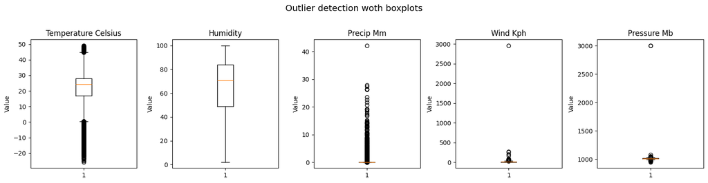

### 2.3 Normalizing data

We'll normalize numerical features for model training (keeping originals for visualization).

```
Normalized data statistics:
```

|  | temperature_celsius | humidity | precip_mm | wind_kph | pressure_mb | visibility_km | uv_index | cloud |
| --- | --- | --- | --- | --- | --- | --- | --- | --- |
| count | 117323.000 | 117323.000 | 117323.000 | 117323.000 | 117323.000 | 117323.000 | 117323.000 | 117323.000 |
| mean | 0.637 | 0.650 | 0.003 | 0.003 | 0.033 | 0.299 | 0.218 | 0.398 |
| std | 0.123 | 0.246 | 0.014 | 0.004 | 0.005 | 0.082 | 0.220 | 0.340 |
| min | 0.000 | 0.000 | 0.000 | 0.000 | 0.000 | 0.000 | 0.000 | 0.000 |
| 25% | 0.571 | 0.480 | 0.000 | 0.001 | 0.031 | 0.312 | 0.012 | 0.000 |
| 50% | 0.667 | 0.704 | 0.000 | 0.003 | 0.033 | 0.312 | 0.147 | 0.290 |
| 75% | 0.719 | 0.837 | 0.001 | 0.005 | 0.034 | 0.312 | 0.368 | 0.750 |
| max | 1.000 | 1.000 | 1.000 | 1.000 | 1.000 | 1.000 | 1.000 | 1.000 |

## 3. Exploratory Data Analysis (EDA)

### 3.1 Data overview

```
Date range: 2024-05-16 01:45:00 to 2026-01-09 20:15:00
Number of countries: 211
Number of locations: 256
```

### 3.2 Temperature analysis

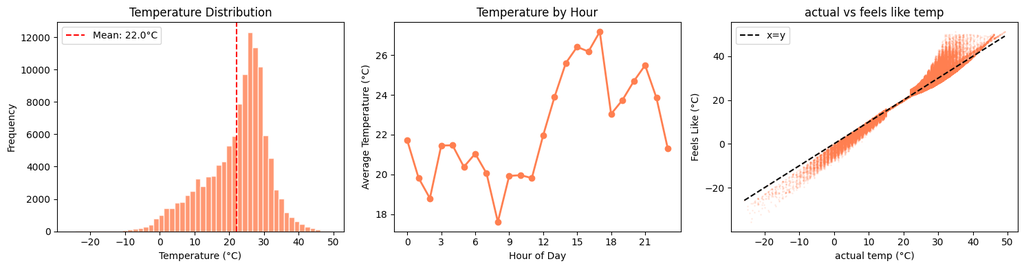

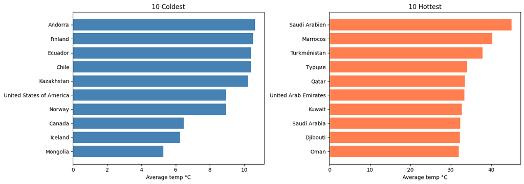

### 3.3 Precipitation analysis

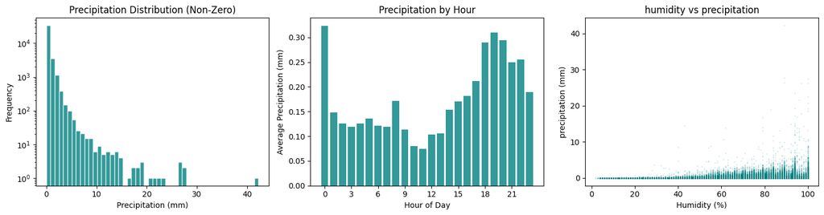

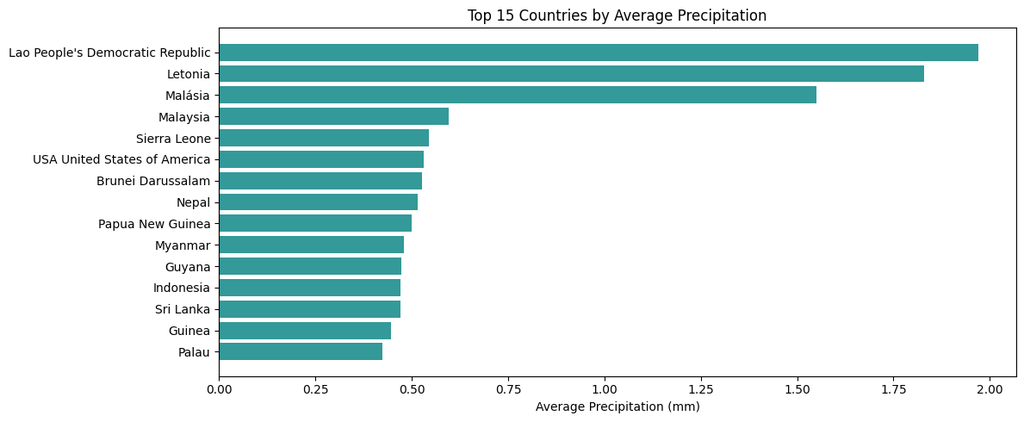

### 3.4 Correlations

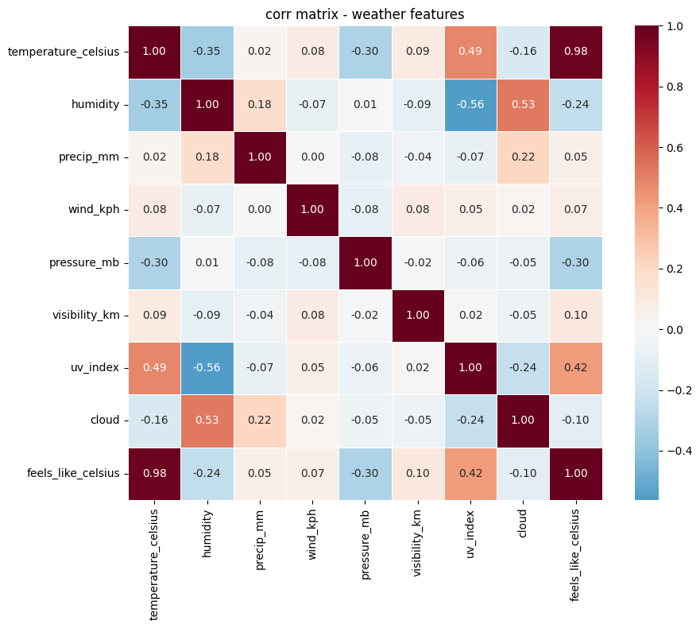

```
                     temperature_celsius  humidity  precip_mm  wind_kph  \
temperature_celsius             1.000000 -0.347075   0.024825  0.084123
humidity                       -0.347075  1.000000   0.177524 -0.070093
precip_mm                       0.024825  0.177524   1.000000  0.003994
wind_kph                        0.084123 -0.070093   0.003994  1.000000
pressure_mb                    -0.301767  0.006207  -0.080375 -0.081864
visibility_km                   0.093715 -0.091520  -0.041868  0.082819
uv_index                        0.487066 -0.562372  -0.069909  0.054164
cloud                          -0.157929  0.528022   0.215804  0.018608
feels_like_celsius              0.981352 -0.241208   0.054418  0.065474

                     pressure_mb  visibility_km  uv_index     cloud  \
temperature_celsius    -0.301767       0.093715  0.487066 -0.157929
humidity                0.006207      -0.091520 -0.562372  0.528022
precip_mm              -0.080375      -0.041868 -0.069909  0.215804
wind_kph               -0.081864       0.082819  0.054164  0.018608
pressure_mb             1.000000      -0.017622 -0.060393 -0.049839
visibility_km          -0.017622       1.000000  0.016487 -0.047503
uv_index               -0.060393       0.016487  1.000000 -0.235841
cloud                  -0.049839      -0.047503 -0.235841  1.000000
feels_like_celsius     -0.301604       0.103308  0.424132 -0.099647

                     feels_like_celsius
temperature_celsius            0.981352
humidity                      -0.241208
precip_mm                      0.054418
wind_kph                       0.065474
pressure_mb                   -0.301604
visibility_km                  0.103308
uv_index                       0.424132
cloud                         -0.099647
feels_like_celsius             1.000000
```

```
Strongest correlations with temperature:
----------------------------------------
feels_like_celsius        : +0.981
uv_index                  : +0.487
humidity                  : -0.347
pressure_mb               : -0.302
cloud                     : -0.158
visibility_km             : +0.094
wind_kph                  : +0.084
precip_mm                 : +0.025
```

### 3.5 Weather conditions

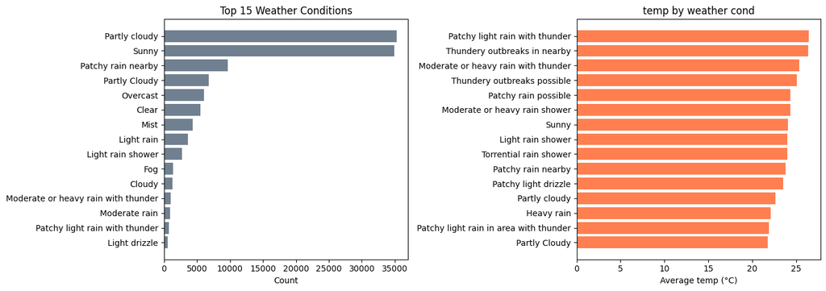

## 4. Forecasting with just one city

### For the time series forecasting task, I selected a single location rather than using the entire dataset. This decision is grounded in fundamental time series theory: forecasting models learn temporal patterns from sequential observations of the same entity over time. Mixing data from multiple locations would violate the stationarity assumption and introduce confounding factors (different climates, hemispheres, timezones), making it impossible for the model to learn meaningful temporal dependencies. Kabul was selected because it had the highest number of records in the dataset (603 observations), providing the longest time span for the model to learn daily and seasonal patterns. An alternative approach would be to treat this as a regression problem using all locations with geographical features as inputs, but that would no longer be time series forecasting in the classical sense.

### 4.1 Feature engineering in order to select the city with most records

```
location: Kabul (603)
```

```
Features shape: (603, 9)
Target shape: (603,)
```

### 4.2 training the model

```
train set: 482 x
test set: 121 y
```

### 4.3 Model eval

```
model performance:
```

|  | Model | RMSE | MAE | R² |
| --- | --- | --- | --- | --- |
| 0 | Random forest | 1.6884 | 1.2758 | 0.9769 |

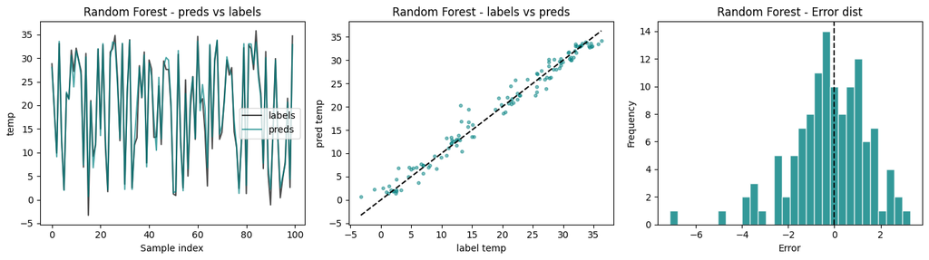

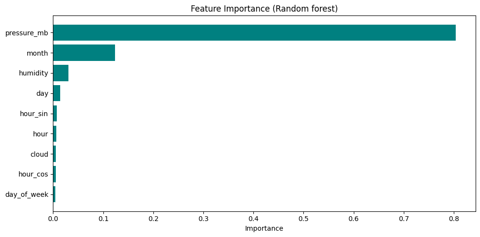

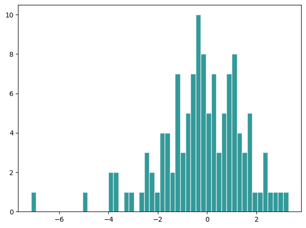

```
mean error of random forest: -0.227°C
standard error of random forest: 1.680°C
```

## ADVANCED ASSESMENT

### 2. Forecasting with multiple models

### now a visual comparison of the three models

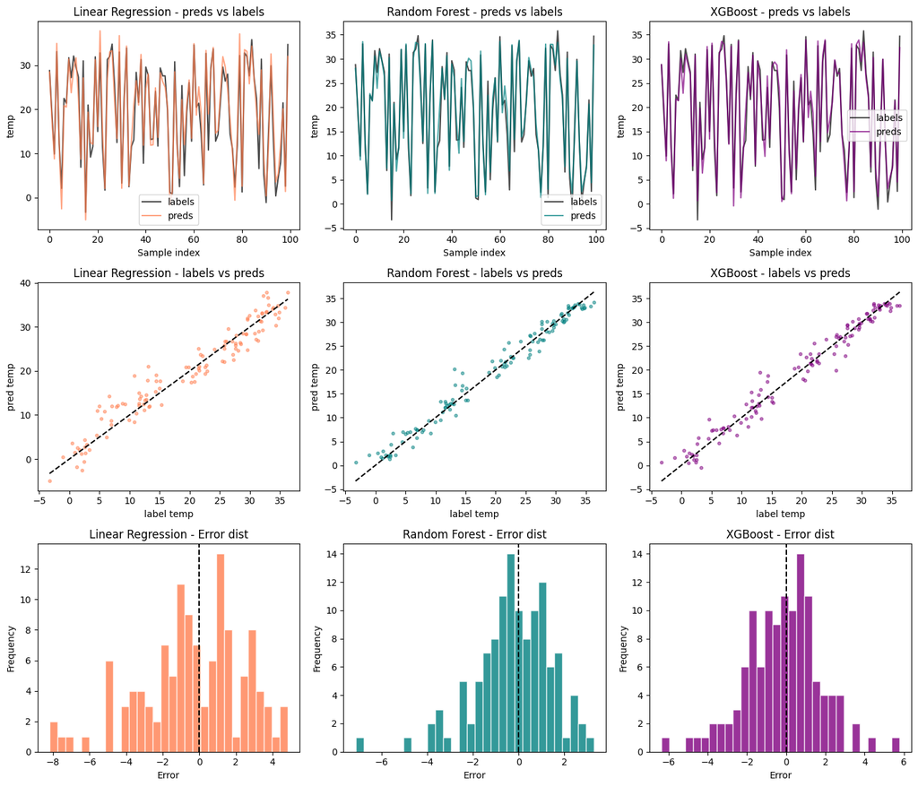

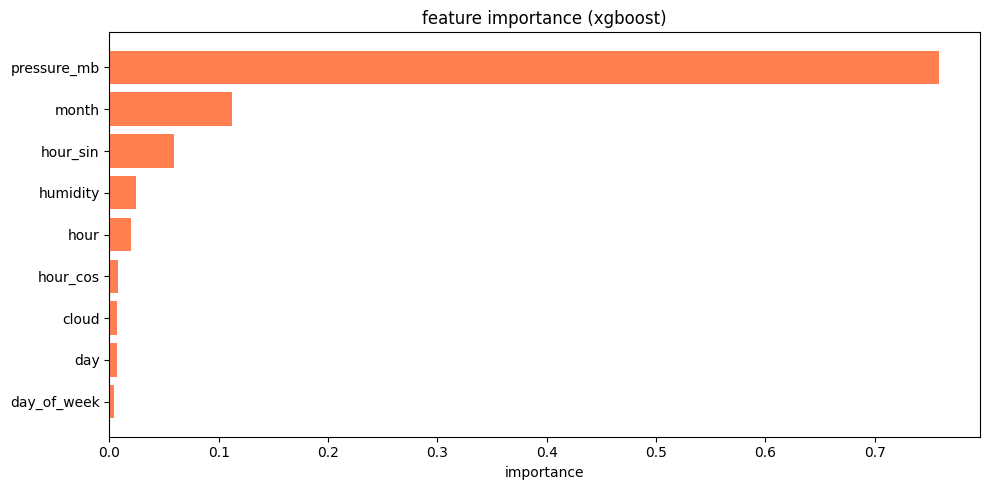

```
model performance:
```

|  | Model | RMSE | MAE | R² |
| --- | --- | --- | --- | --- |
| 0 | Linear regr. | 2.8402 | 2.2563 | 0.9346 |
| 1 | Random Forest | 1.6884 | 1.2758 | 0.9769 |
| 2 | XGBoost | 1.9087 | 1.4679 | 0.9704 |

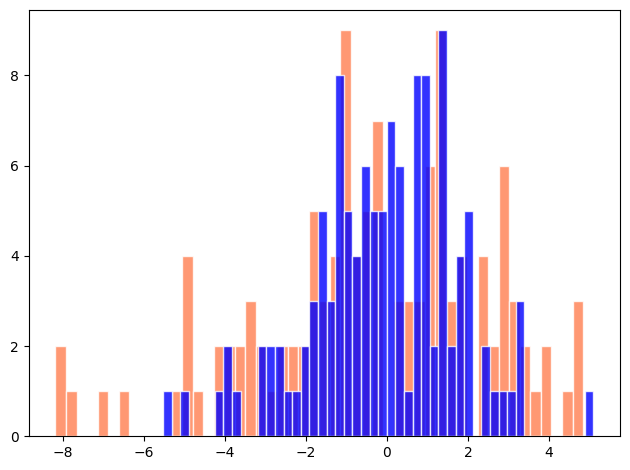

```
mean error of linear regression: -0.370°C
standard error of linear regression: 2.828°C
mean error of xgboost: -0.098°C
standard error of xgboost: 1.814°C
```

### 3. Unique analysis

#### 3.2 env impact - air quality

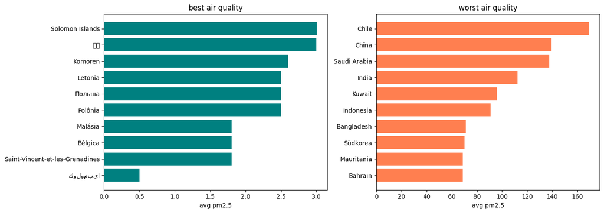

## 5. Conclusions

### ADVANCED ASSIGNMENT

TO SAY IS THAT IN THE ADVANCED ASSIGNMENT IT WAS REQUIRED TO MAKE AN ENSEMBLE METHOD THAT COMBINES ALL THREE PREDICTIONS, BUT I SUPPOSED THAT DUE TO THE FACT THAT AS RANDOM FOREST AND XG BOOST ARE ALREADY ENSEMBLE METHOD MODELS, I THINK THEY WERE ALREADY GOING TO MAKE A QUITE GOOD PREDICTION.

Nevertheless, an ensemble method combining the three could be made by just making a simple average ensemble as follows:

ensemble_pred = (linear_pred + rf_pred + xgb_pred) / 3